# intersubject discrimination (ID): mathematical definitions and simulation

# 1 definitions

## 1.1 mutivariate and univariate distance measures

Let $x_{sv}$ be the b-coefficient estimate for subject $s \in 1, \ldots, S$ and for vertex $v \in 1, \ldots, V$ vertices, from fold 1 of the experiment. Fold 1 could be, e.g., run 1, or could be the “test” phase. Let $y_{tv}$ be an analogous estimate from fold 2 of the experiment (e.g., run 2 or “retest” phase), for a not-necessarily-different subject $t \in 1, \ldots, S$. These estimates are elements of matrices $\mathbf{X}$ and $\mathbf{Y}$, both of size $S\times V$.

**Multivariate distance measure**: the squared Euclidean distance between vectors $x_s$ and $y_t$.

$$\mathit{m}_{st} = \frac{1}{V}\sum_{v=1}^{V} (x_{sv} - y_{tv})^2$$

We scale by the number of vertices $V$ to aid comparability across regions of interest.

**Univariate distance measure**: the squared Euclidean distance between *the sum of the elements of* vectors $x_s$ and of $y_t$.

$$\bar x_{s} = \sum_{v=1}^{V}x_{sv}$$
$$\bar y_{t} = \sum_{v=1}^{V}y_{tv}$$
$$\mathit{u}_{st} = \frac{1}{V}(\bar x_{s} - \bar y_{t})^2$$

Because the sum of the elements of a vector is a scalar, here, the squared Euclidean distance simplifies to the squared difference between the terms.

## 1.2 intersubject discrimination index (IDI)

The cross-fold multivariate distances, $\mathit{m}_{st}$, can be collated into the $S\times S$ matrix $\mathbf{M}$. Analogously, the univariate distances, $\mathit{u}_{st}$, can be collated into an $S\times S$ matrix $\mathbf{U}$. These matrices are cross-fold distance matrices: asymmetric, with rows corresponding to fold 1, and columns corresponding to fold 2. Their diagonal elements contain within-subject distances, while the off-diagonal elements contain cross-subject distances.

The IDI is computed via a contrast on these cross-fold distance matrices. The IDI is defined as the mean of the cross-subject distances (off-diagonal elements) minus the mean of the within-subject distances (diagonal elements). Formally, for an arbitrary $S\times S$ cross-fold distance matrix $\mathbf{D}$,

$$\mathit{idi}(\mathbf{D}_{S\times S}) =
\frac{\sum_{s=1,t>s}^{S}d_{st} + \sum_{s>t,t=1}^{S}d_{st}}{S^2-S} - \frac{tr(\mathbf{D})}{S}$$

The multivariate and univariate IDI statistics can now be defined as

$$\mathit{mIDI} = \mathit{idi}(\mathbf{M})$$

and

$$\mathit{uIDI} = \mathit{idi}(\mathbf{U})$$

# 2 simulations

```r
knitr::opts_chunk$set(cache = TRUE)

library(knitr)
library(MASS)
library(RColorBrewer)

euclidean2 <- function(x, y) sum((x - y)^2)  ## squared euclidean distance; works on vectors


pdist2 <- function(A,B) {

  ## this function works on matrices A and B.
  ## A and B should be matrices with subjects as rows and vertices as columns.
  ## A and B should be from separate folds (i.e., "test" and "retest" or "run1" and "run2").

  ## this function computes the squared euclidean distances between each row of A and each row of B.
  ## the output is therefore a matrix of size nrow(A)*nrow(B), i.e., Sects * Sects.

  ## this is an efficient implementation of the pdist::pdist function.
  ## see links for more information:
  ## https://www.r-bloggers.com/2013/05/pairwise-distances-in-r/
  ## https://blog.smola.org/post/969195661/in-praise-of-the-second-binomial-formula


  an = apply(A, 1, function(rvec) crossprod(rvec,rvec))
  bn = apply(B, 1, function(rvec) crossprod(rvec,rvec))

  m = nrow(A)
  n = nrow(B)

  tmp = matrix(rep(an, n), nrow=m)
  tmp = tmp +  matrix(rep(bn, m), nrow=m, byrow=TRUE)

  tmp - 2 * tcrossprod(A,B)  ## squared euclidean distance

}


idi <- function(x) {

  ## this function works on square distance matrices, and computes the "intersubject discrimination index".
  ## it subtracts the mean diagonal from the mean of the off diagonals.

  offdiag <- x[row(x) != col(x)]
  diagonal <- diag(x)

  mean(offdiag) - mean(diagonal)

}


n_sim <- 1E4  ## number replicates
V <- 100  ## number voxels
S <- 55  ## number subjects


rf <- colorRampPalette(rev(brewer.pal(11, 'Spectral')))  ## for palette
r <- rf(32)
```

## 2.1 multivariate and univariate distance measures

### 2.1.1 no effect

```r
d <- as.data.frame(matrix(NA, ncol = 2, nrow = n_sim))
names(d) <- c("m", "u")

for (ii in 1:n_sim) {

  x <- rnorm(V)
  y <- rnorm(V)

  d$m[ii] <- euclidean2(x, y) / V  ## multivariate distance
  d$u[ii] <- euclidean2(sum(x), sum(y)) / V  ## univariate distance

}
```

Expected values seem to be equivalent. However, variance (and PDF) differs depending on V.

```r
colMeans(d)
```

```
##        m        u
## 2.003230 2.051313
```

```r
apply(d, 2, var)
```

```
##         m         u
## 0.0818699 8.2282440
```

```r
t.test(d$m, d$u, paired = TRUE)$statistic
```

```
##        t
## -1.68437
```

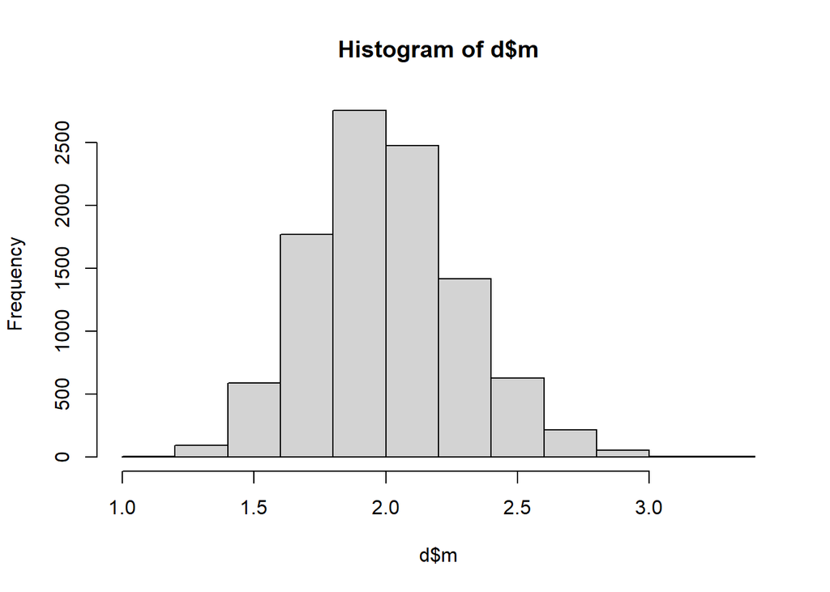

```r
hist(d$m)
```

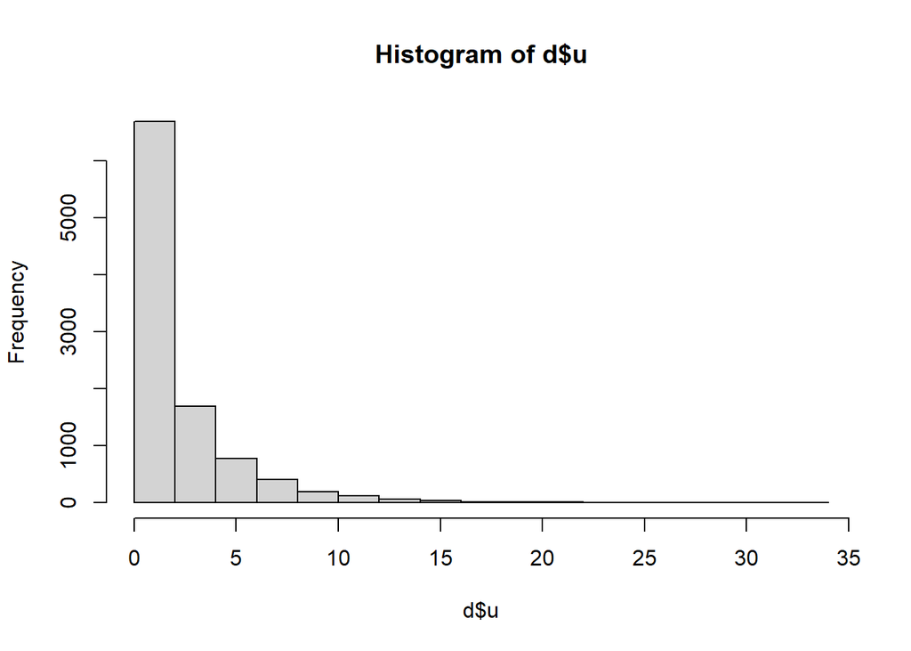

```r
hist(d$u)
```

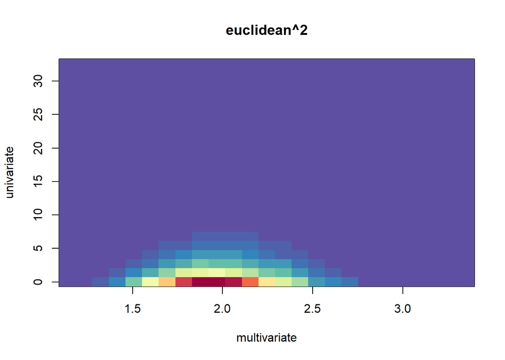

```r
kernel_d2 <- kde2d(d$m, d$u)
image(kernel_d2, col = r, main = "euclidean^2", xlab = "multivariate", ylab = "univariate")
```

Taking square root breaks equivalence of expected values.

```r
colMeans(sqrt(d))
```

```
##        m        u
## 1.411763 1.146997
```

```r
t.test(sqrt(d$m), sqrt(d$u), paired = TRUE)$statistic
```

```
##        t
## 30.99758
```

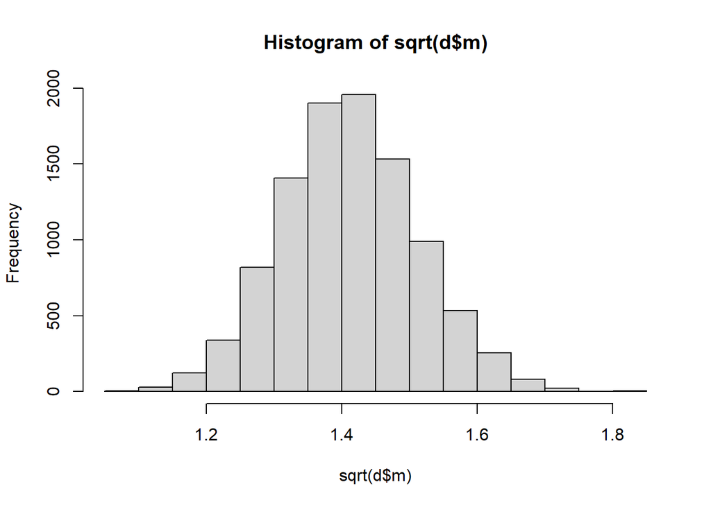

```r
hist(sqrt(d$m))
```

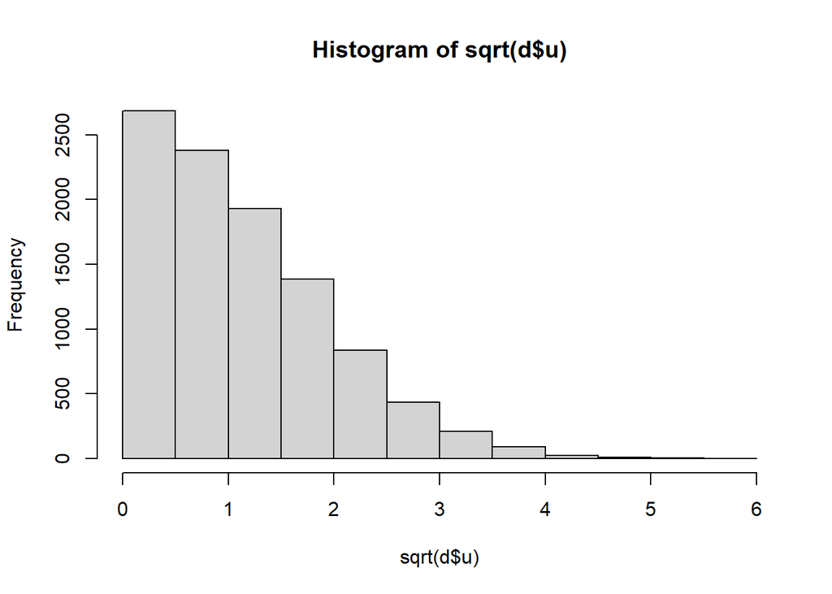

```r
hist(sqrt(d$u))
```

```r
apply(sqrt(d), 2, var)
```

```
##          m          u
## 0.01015476 0.73578542
```

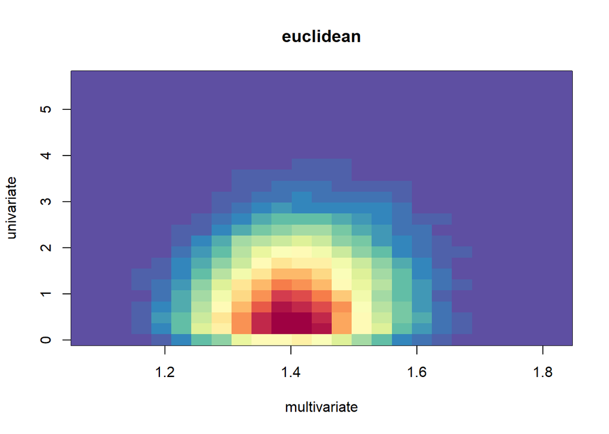

```r
kernel_d <- kde2d(sqrt(d$m), sqrt(d$u))
image(kernel_d, col = r, main = "euclidean", xlab = "multivariate", ylab = "univariate")
```

These simulated distributions are well-matched by the Chi-square distributions, with *df* of either 1 (for univariate measure) or V (for multivariate measure).

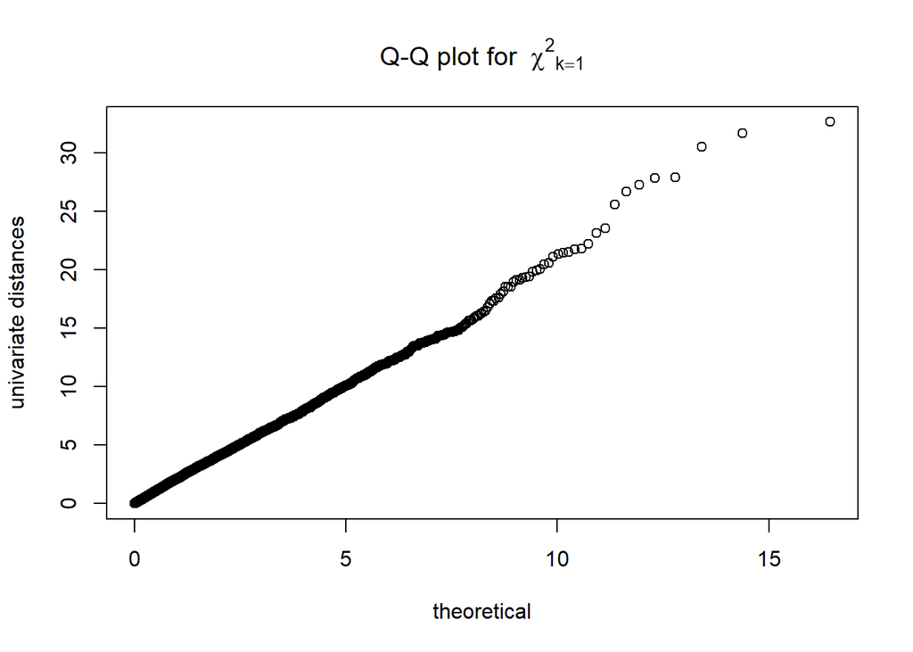

```r
qqplot(
  qchisq(ppoints(n_sim), df = 1),
  d$u,
  main = expression("Q-Q plot for" ~~ {chi^2}[k == 1]),
  xlab = "theoretical",
  ylab = "univariate distances"
  )
```

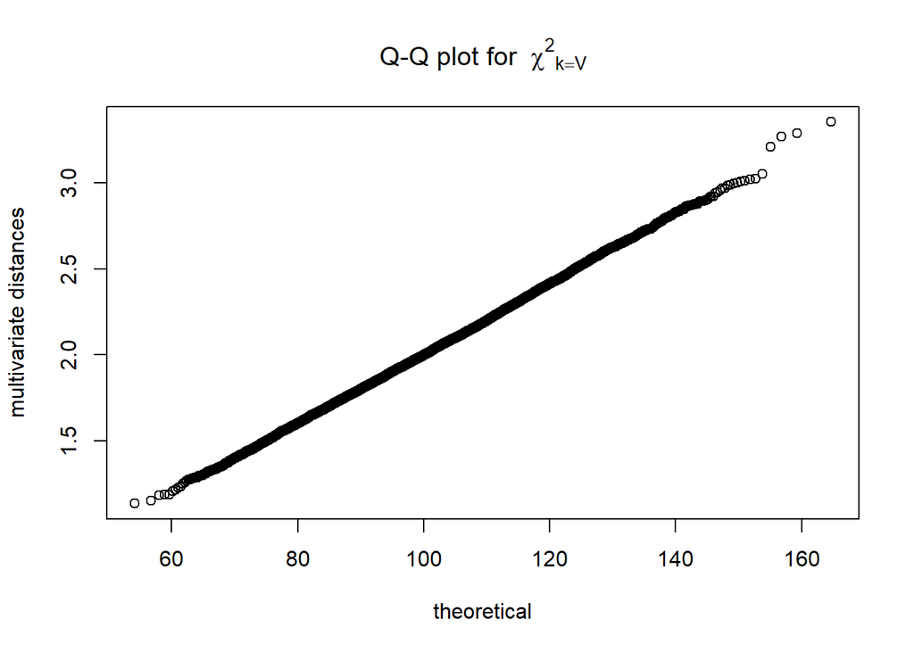

```r
qqplot(
  qchisq(ppoints(n_sim), df = V),
  d$m,
  main = expression("Q-Q plot for" ~~ {chi^2}[k == V]),
  xlab = "theoretical",
  ylab = "multivariate distances"
  )
```

### 2.1.2 univariate (uniform) effect

```r
d_univ <- as.data.frame(matrix(NA, ncol = 2, nrow = n_sim))
names(d_univ) <- c("m", "u")

for (ii in 1:n_sim) {

  x <- rnorm(V)
  y <- rnorm(V, mean = 1)

  d_univ$m[ii] <- euclidean2(x, y) / V
  d_univ$u[ii] <- euclidean2(sum(x), sum(y)) / V

}
```

Now the univariate distance is larger.

```r
colMeans(d_univ)
```

```
##          m          u
##   2.994997 101.610027
```

```r
apply(d_univ, 2, var)
```

```
##          m          u
##   0.157139 781.672186
```

```r
t.test(d_univ$m, d_univ$u, paired = TRUE)$statistic
```

```
##        t
## -356.265
```

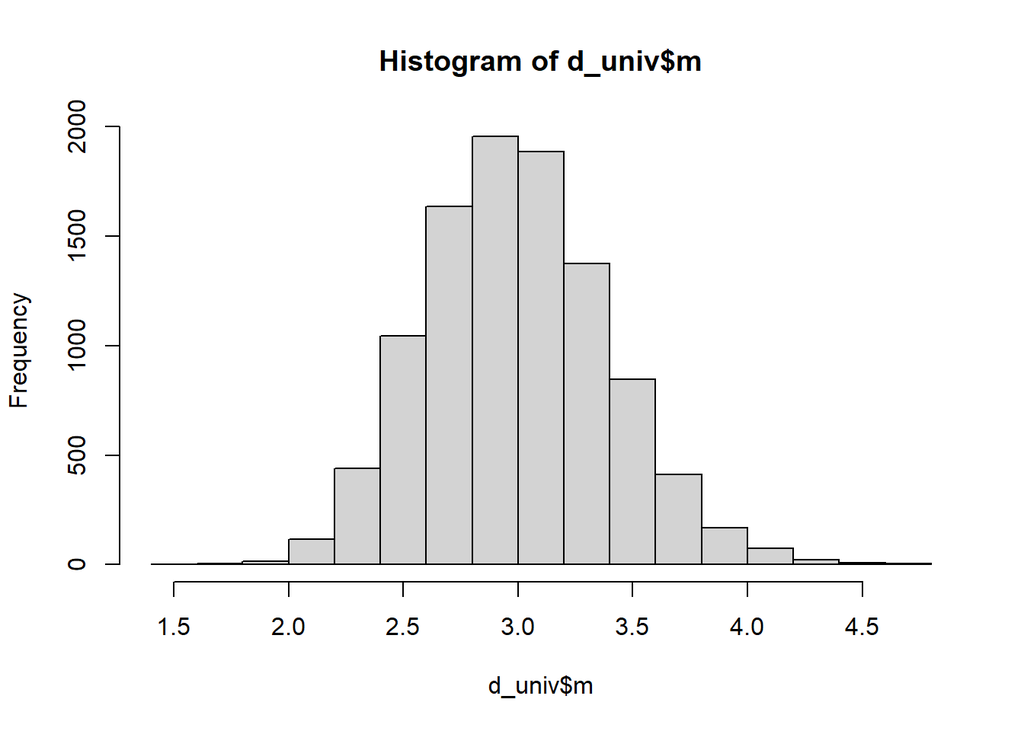

```r
hist(d_univ$m)
```

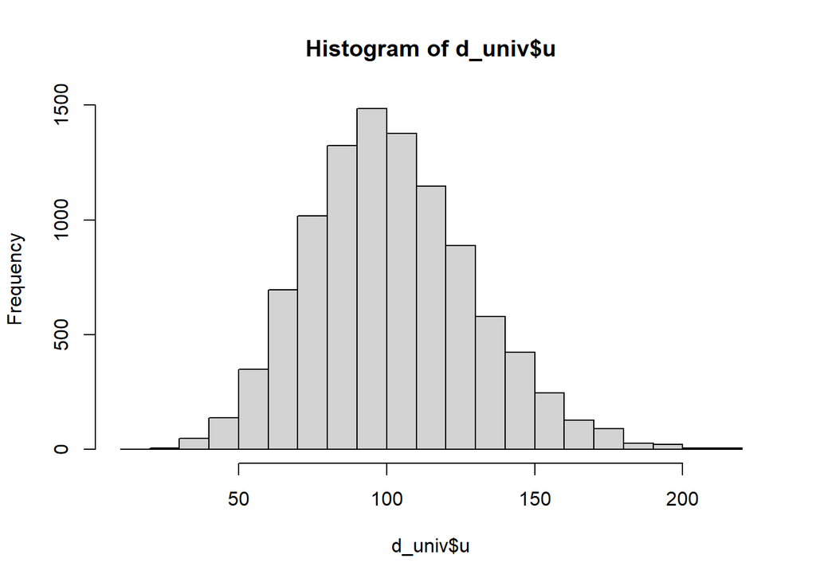

```r
hist(d_univ$u)
```

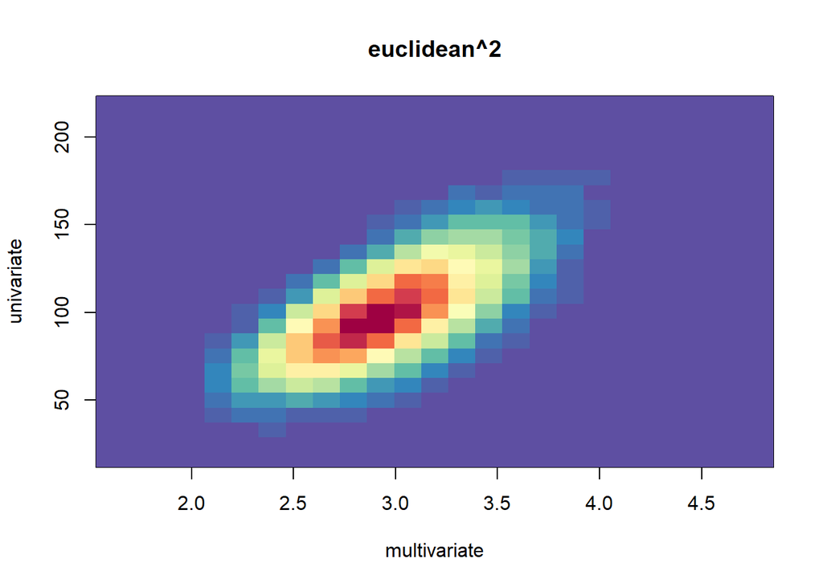

```r
kernel_d2_univ <- kde2d(d_univ$m, d_univ$u)
image(kernel_d2_univ, col = r, main = "euclidean^2", xlab = "multivariate", ylab = "univariate")
```

### 2.1.3 multivariate (non-uniform) effect

```r
d_multiv <- as.data.frame(matrix(NA, ncol = 2, nrow = n_sim))
names(d_multiv) <- c("m", "u")

subj_pattern <- scale(rnorm(V), scale = FALSE)  ## no univariate effect

for (ii in 1:n_sim) {

  x <- rnorm(V) + subj_pattern  ## pattern across vertices, but across-voxel mean of 0
  y <- rnorm(V) - subj_pattern  ## opposite pattern

  d_multiv$m[ii] <- euclidean2(x, y) / V  ## multivariate distance
  d_multiv$u[ii] <- euclidean2(sum(x), sum(y)) / V  ## univariate distance

}
```

Now the multivariate distance is larger.

```r
colMeans(d_multiv)
```

```
##        m        u
## 5.856612 1.986567
```

```r
apply(d_multiv, 2, var)
```

```
##         m         u
## 0.3921285 7.6439242
```

```r
t.test(d_multiv$m, d_multiv$u, paired = TRUE)$statistic
```

```
##        t
## 137.4055
```

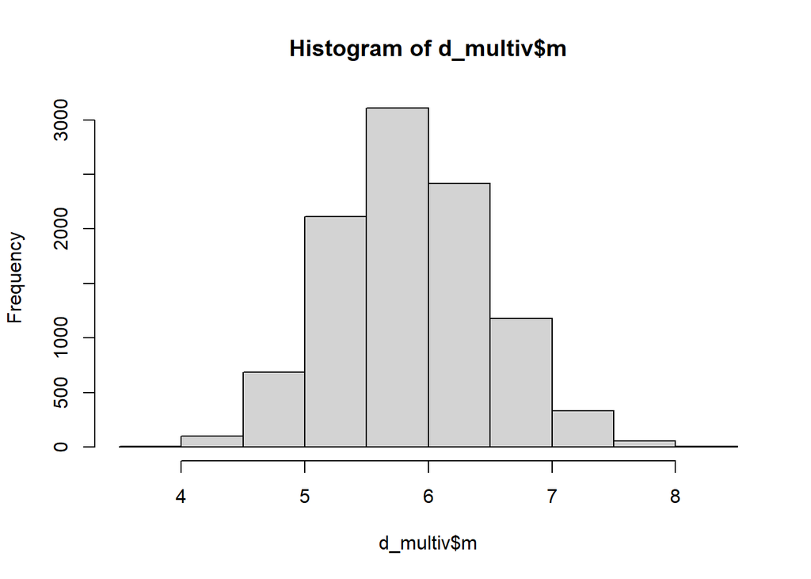

```r
hist(d_multiv$m)
```

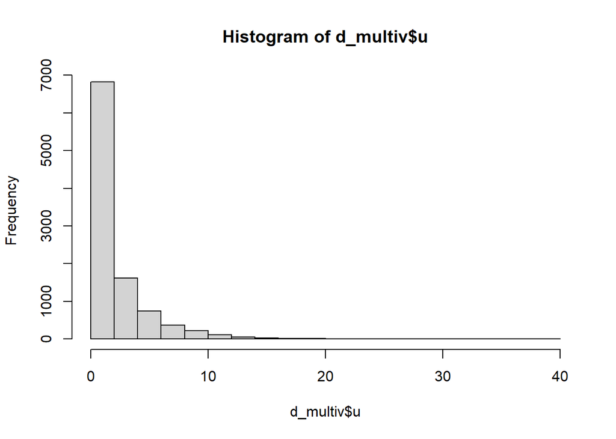

```r
hist(d_multiv$u)
```

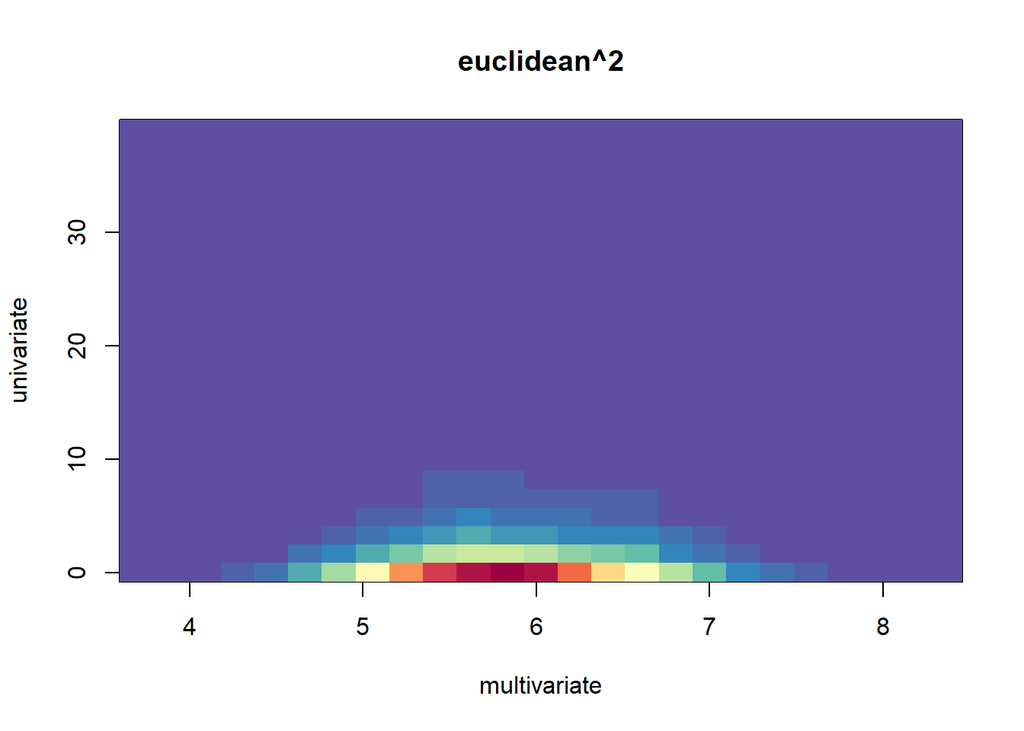

```r
kernel_d2_multiv <- kde2d(d_multiv$m, d_multiv$u)
image(kernel_d2_multiv, col = r, main = "euclidean^2", xlab = "multivariate", ylab = "univariate")
```

## 2.2 intersubject discrimination index (IDI)

### 2.2.1 no effect

```r
d <- as.data.frame(matrix(NA, ncol = 2, nrow = n_sim))
names(d) <- c("m", "u")

for (ii in 1:n_sim) {

  X <- matrix(rnorm(V*S), nrow = S)
  Y <- matrix(rnorm(V*S), nrow = S)
  ## X is a matrix of b-coefficients. subjects as rows, vertices as columns. from fold 1 (e.g., "test").
  ## Y is also a b-coefficient matrix. organized identically to X, but from a different "fold" (e.g., "retest").

  X_bar <- cbind(rowSums(X))  ## across-vertex sum of b-coefficients. one per subj.
  Y_bar <- cbind(rowSums(Y))

  M <- pdist2(X, Y)  ## multivariate distance
  U <- pdist2(X_bar, Y_bar) ## univariate distance

  d$m[ii] <- idi(M)  ## mIDI
  d$u[ii] <- idi(U)  ## uIDI

}
```

```r
colMeans(d)
```

```
##           m           u
## -0.01753819  0.08624014
```

```r
apply(d, 2, var)
```

```
##          m          u
##   7.652042 734.826230
```

```r
apply(d, 2, function(x) t.test(x)$statistic)
```

```
##          m          u
## -0.6340099  0.3181392
```

```r
apply(d, 2, function(x) wilcox.test(x)$p.value)
```

```
##         m         u
## 0.4597985 0.9071346
```

```r
t.test(d$m, d$u, paired = TRUE)$statistic
```

```
##         t
## -0.384951
```

```r
wilcox.test(d$m, d$u, paired = TRUE)$p.value
```

```
## [1] 0.8512256
```

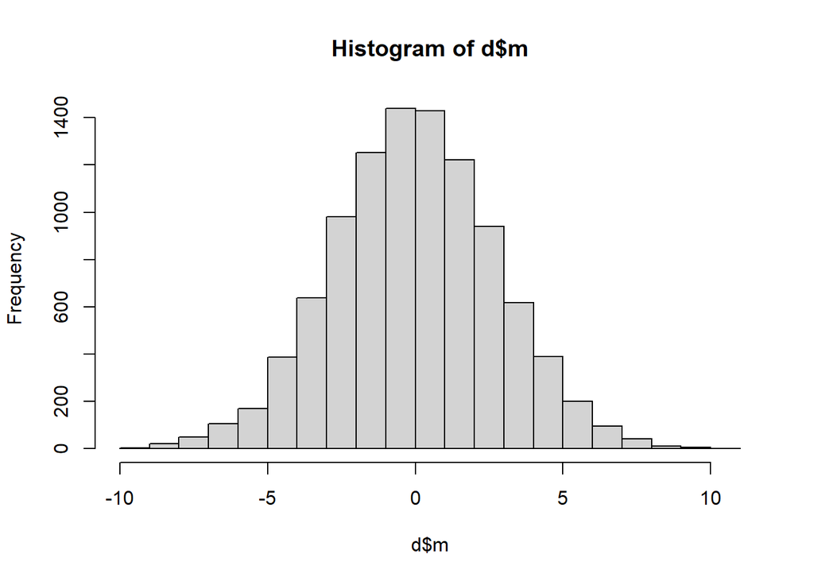

```r
hist(d$m)
```

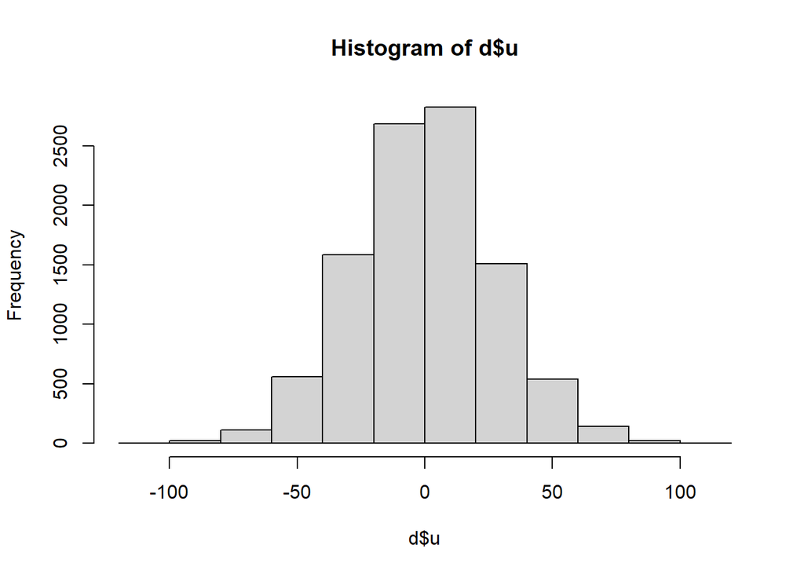

```r
hist(d$u)
```

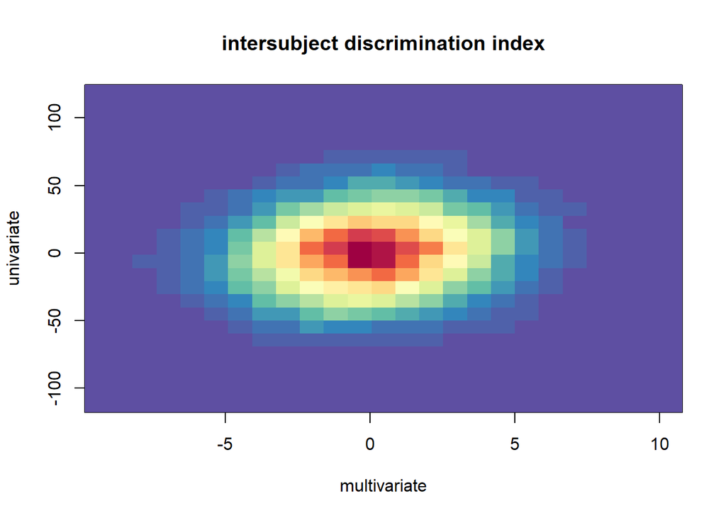

```r
kernel_d2 <- kde2d(d$m, d$u)
image(kernel_d2, col = r, main = "intersubject discrimination index", xlab = "multivariate", ylab = "univariate")
```

### 2.2.2 univariate (uniform) effect

```r
d_univ <- as.data.frame(matrix(NA, ncol = 2, nrow = n_sim))
names(d_univ) <- c("m", "u")

for (ii in 1:n_sim) {

  subj_means <- matrix(rnorm(S), nrow = V, ncol = S, byrow = TRUE)
  X <- matrix(rnorm(V*S), ncol = S) + subj_means  ## add a pattern to each row
  Y <- matrix(rnorm(V*S), ncol = S) + subj_means

  d_univ$m[ii] <- idi(pdist2(t(X), t(Y)) / V)  ## multivariate distance
  d_univ$u[ii] <- idi(pdist2(cbind(colSums(X)), cbind(colSums(Y))) / V)  ## univariate distance

}
```

Now the univariate distance is larger.

```r
colMeans(d_univ)
```

```
##         m         u
##   2.00093 200.09764
```

```r
apply(d_univ, 2, var)
```

```
##            m            u
##    0.1464083 1456.2206554
```

```r
t.test(d_univ$m, d_univ$u, paired = TRUE)$statistic
```

```
##         t
## -524.3595
```

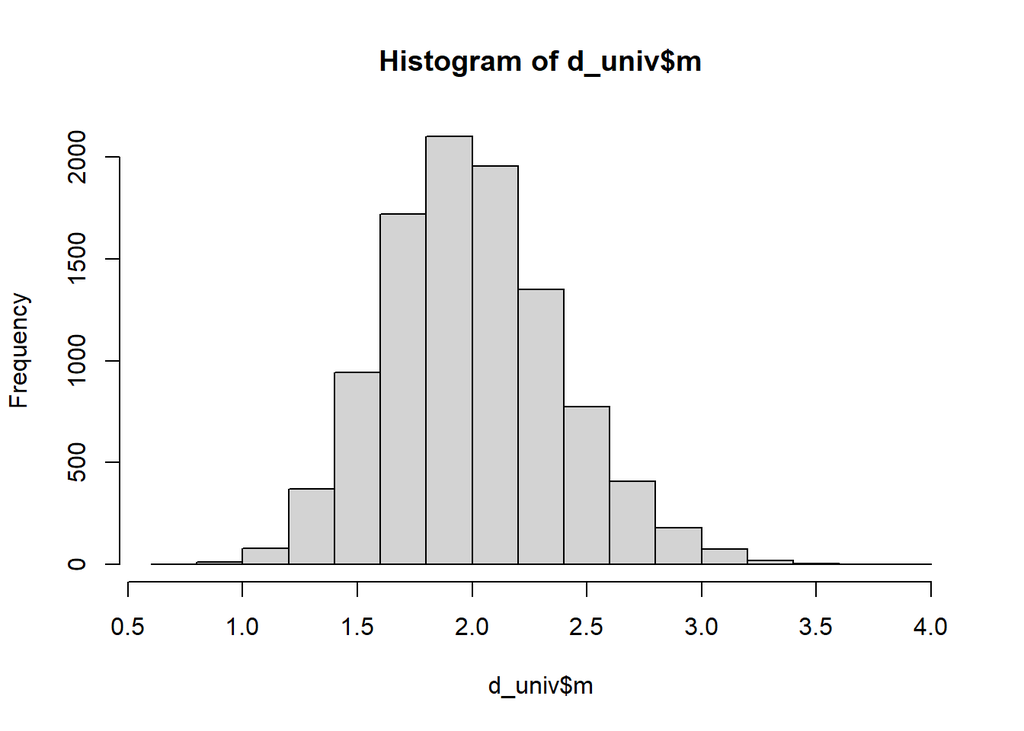

```r
hist(d_univ$m)
```

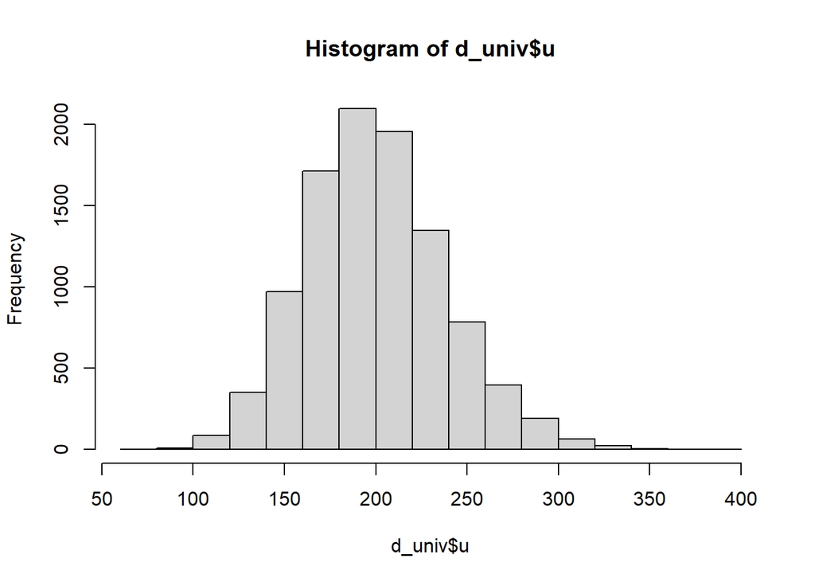

```r
hist(d_univ$u)
```

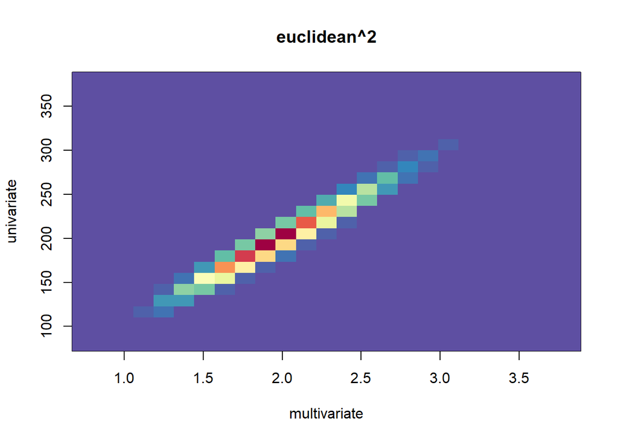

```r
kernel_d2_univ <- kde2d(d_univ$m, d_univ$u)
image(kernel_d2_univ, col = r, main = "euclidean^2", xlab = "multivariate", ylab = "univariate")
```

### 2.2.3 multivariate (non-uniform) effect

```r
d_multiv <- as.data.frame(matrix(NA, ncol = 2, nrow = n_sim))
names(d_multiv) <- c("m", "u")

for (ii in 1:n_sim) {

  subj_patterns <- matrix(rnorm(V*S), ncol = S)
  subj_patterns <- scale(subj_patterns, scale = FALSE)
  X <- matrix(rnorm(V*S), ncol = S) + subj_patterns
  Y <- matrix(rnorm(V*S), ncol = S) + subj_patterns

  d_multiv$m[ii] <- idi(pdist2(t(X), t(Y)) / V)  ## multivariate distance
  d_multiv$u[ii] <- idi(pdist2(cbind(colSums(X)), cbind(colSums(Y))) / V)  ## univariate distance

}
```

Now the multivariate distance is larger.

```r
colMeans(d_multiv)
```

```
##            m            u
## 1.9799802700 0.0009159419
```

```r
apply(d_multiv, 2, var)
```

```
##           m           u
## 0.003584222 0.074418530
```

```r
t.test(d_multiv$m, d_multiv$u, paired = TRUE)$statistic
```

```
##        t
## 713.7884
```

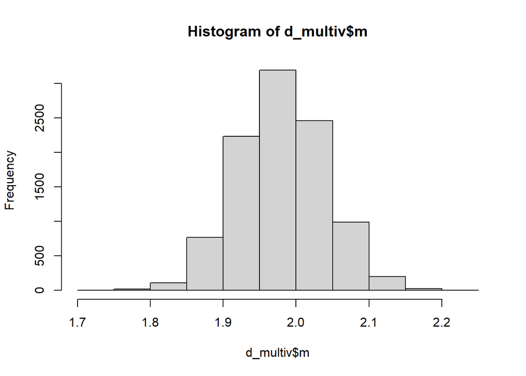

```r
hist(d_multiv$m)
```

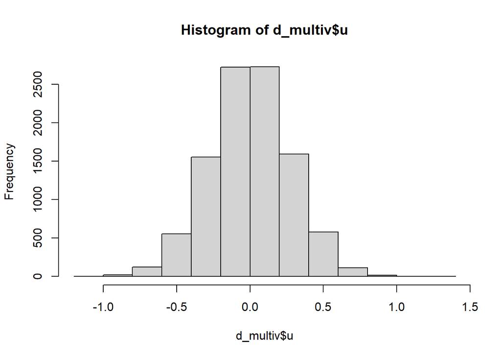

```r
hist(d_multiv$u)
```

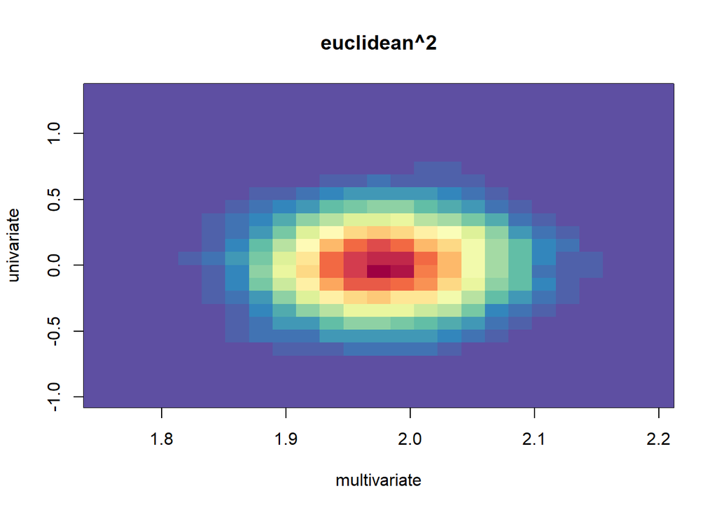

```r
kernel_d2_multiv <- kde2d(d_multiv$m, d_multiv$u)
image(kernel_d2_multiv, col = r, main = "euclidean^2", xlab = "multivariate", ylab = "univariate")
```